# USP654 Lab 7: Nonlinear Relationship

11/06/2017

## Testing Differences in Means Among the Included Groups with Interactions

```r
require(tidyverse)

# create an artificial housework chore dataset
chores <- mtcars %>% select(hours=mpg, married=vs, women=am)
rownames(chores) <- NULL

lm(hours ~ married * women, data=chores) %>%
  summary
```

```
##
## Call:
## lm(formula = hours ~ married * women, data = chores)
##
## Residuals:
##    Min     1Q Median     3Q    Max
## -6.971 -1.973  0.300  2.036  6.250
##
## Coefficients:
##               Estimate Std. Error t value Pr(>|t|)
## (Intercept)     15.050      1.002  15.017 6.34e-15 ***
## married          5.693      1.651   3.448   0.0018 **
## women            4.700      1.736   2.708   0.0114 *
## married:women    2.929      2.541   1.153   0.2589
## ---
## Signif. codes:  0 '***' 0.001 '**' 0.01 '*' 0.05 '.' 0.1 ' ' 1
##
## Residual standard error: 3.472 on 28 degrees of freedom
## Multiple R-squared:  0.7003, Adjusted R-squared:  0.6682
## F-statistic: 21.81 on 3 and 28 DF,  p-value: 1.735e-07
```

1. Redefine reference category

```r
chores <- chores %>% mutate(unmarried = !married, men=!women)

lm(hours ~ unmarried * women, data=chores) %>%
  summary
```

```
##
## Call:
## lm(formula = hours ~ unmarried * women, data = chores)
##
## Residuals:
##    Min     1Q Median     3Q    Max
## -6.971 -1.973  0.300  2.036  6.250
##
## Coefficients:
##                     Estimate Std. Error t value Pr(>|t|)
## (Intercept)           20.743      1.312  15.808 1.75e-15 ***
## unmarriedTRUE         -5.693      1.651  -3.448 0.001805 **
## women                  7.629      1.856   4.111 0.000312 ***
## unmarriedTRUE:women   -2.929      2.541  -1.153 0.258855
## ---
## Signif. codes:  0 '***' 0.001 '**' 0.01 '*' 0.05 '.' 0.1 ' ' 1
##
## Residual standard error: 3.472 on 28 degrees of freedom
## Multiple R-squared:  0.7003, Adjusted R-squared:  0.6682
## F-statistic: 21.81 on 3 and 28 DF,  p-value: 1.735e-07
```

```r
lm(hours ~ married * men, data=chores) %>%
  summary
```

```
##
## Call:
## lm(formula = hours ~ married * men, data = chores)
##
## Residuals:
##    Min     1Q Median     3Q    Max
## -6.971 -1.973  0.300  2.036  6.250
##
## Coefficients:
##                 Estimate Std. Error t value Pr(>|t|)
## (Intercept)       19.750      1.417  13.935 4.06e-14 ***
## married            8.621      1.931   4.464  0.00012 ***
## menTRUE           -4.700      1.736  -2.708  0.01142 *
## married:menTRUE   -2.929      2.541  -1.153  0.25885
## ---
## Signif. codes:  0 '***' 0.001 '**' 0.01 '*' 0.05 '.' 0.1 ' ' 1
##
## Residual standard error: 3.472 on 28 degrees of freedom
## Multiple R-squared:  0.7003, Adjusted R-squared:  0.6682
## F-statistic: 21.81 on 3 and 28 DF,  p-value: 1.735e-07
```

```r
lm(hours ~ unmarried * men, data=chores) %>%
  summary
```

```
##
## Call:
## lm(formula = hours ~ unmarried * men, data = chores)
##
## Residuals:
##    Min     1Q Median     3Q    Max
## -6.971 -1.973  0.300  2.036  6.250
##
## Coefficients:
##                       Estimate Std. Error t value Pr(>|t|)
## (Intercept)             28.371      1.312  21.622  < 2e-16 ***
## unmarriedTRUE           -8.621      1.931  -4.464 0.000120 ***
## menTRUE                 -7.629      1.856  -4.111 0.000312 ***
## unmarriedTRUE:menTRUE    2.929      2.541   1.153 0.258855
## ---
## Signif. codes:  0 '***' 0.001 '**' 0.01 '*' 0.05 '.' 0.1 ' ' 1
##
## Residual standard error: 3.472 on 28 degrees of freedom
## Multiple R-squared:  0.7003, Adjusted R-squared:  0.6682
## F-statistic: 21.81 on 3 and 28 DF,  p-value: 1.735e-07
```

**Q: Do married women and men spend similar hours on housework chores?**

2. Partial F test:
- $H_0: \beta_2 + \beta_2=0$
- $H_A: \beta_2 + \beta_2 \ne 0$

```r
car::lht(lm(hours ~ married*women, data=chores), "women + married:women = 0")
```

```
## Linear hypothesis test
##
## Hypothesis:
## women  + married:women = 0
##
## Model 1: restricted model
## Model 2: hours ~ married * women
##
##   Res.Df    RSS Df Sum of Sq      F    Pr(>F)
## 1     29 541.16
## 2     28 337.48  1    203.68 16.899 0.0003119 ***
## ---
## Signif. codes:  0 '***' 0.001 '**' 0.01 '*' 0.05 '.' 0.1 ' ' 1
```

2. linear combination of coefficients
- The point estimate is $\hat{\beta_2} + \hat{\beta_3}$
- In this case, our linear combination involves the sum rather than the difference between two coefficients, and the formula for estimating the standard error of the sum of two coefficients is:
  $$\sqrt{\hat{\sigma^2_{\hat{\beta_2}}} + \hat{\sigma^2_{\hat{\beta_3}}} + 2\hat{cov}_{\hat{\beta_2}\hat{\beta_3}}}$$
- $H_0: \beta_2 + \beta_2=0$
- $H_A: \beta_2 + \beta_2 \ne 0$

```r
fit1 <- lm(hours ~ married*women, data=chores)
beta2 <- coef(fit1)["women"]
beta3 <- coef(fit1)["married:women"]

betas_vcov <- vcov(fit1)
se <- sqrt(betas_vcov["women", "women"] + betas_vcov["married:women", "married:women"] + 2 * betas_vcov["women", "married:women"])

(t_stat <- (beta2 + beta3)/se)
```

```
##    women
## 4.110877
```

```r
## Degrees of Freedom
dof <- fit1$df.residual

## compare t_stat to critical t-value
(t_crit <- qt(0.025, df=dof, lower.tail = F))
```

```
## [1] 2.048407
```

```r
## OR find the corresponding p-value
(p_val <- 2 * pt(t_stat, lower.tail = F, df=dof))
```

```
##        women
## 0.0003119239
```

**Task**: Does marital status change number of hours women spending on housework chores?

## Nonlinear Relationship

Download california.csv

If you suspect nonlinear relationship between two variables, it is always a good idea to to plot your data:

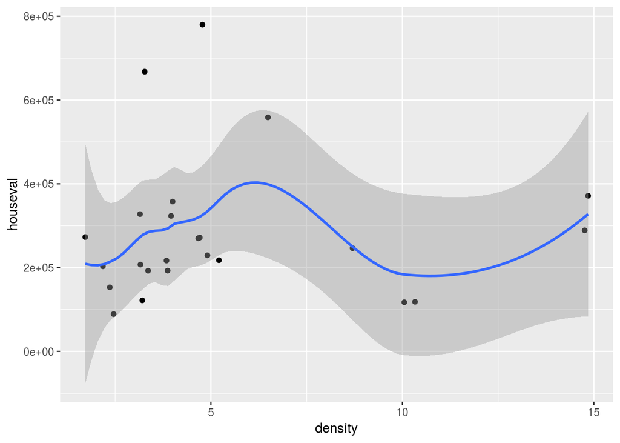

```r
require(tidyverse)
californiatod <- read_csv("californiatod.csv")

require(ggplot2)
ggplot(data=californiatod, aes(x=density, y=houseval)) + geom_point() + geom_smooth()
```

## Add nonlinear terms

In R, you can easily create nonlinear terms by indicating the transformation you want with the corresponding functions:

```r
huxtable::huxreg(
  lm(houseval ~ density, data=californiatod),
  lm(houseval ~ density + I(density^2), data=californiatod),
  lm(houseval ~ log(density), data=californiatod),
  lm(log(houseval) ~ density, data=californiatod),
  lm(log(houseval) ~ log(density), data=californiatod)
  )
```

|  | (1) | (2) | (3) | (4) | (5) |
| --- | --- | --- | --- | --- | --- |
| (Intercept) | 275618.259 *** | 223902.088 | 246143.470 * | 12.379 *** | 12.274 *** |
|  | (60136.917) | (138913.766) | (96727.040) | (0.189) | (0.304) |
| density | 1219.484 | 19240.083 |  | 0.007 |  |
|  | (9423.995) | (44499.566) |  | (0.030) |  |
| I(density^2) |  | -1102.008 |  |  |  |
|  |  | (2657.313) |  |  |  |
| log(density) |  |  | 23732.079 |  | 0.095 |
|  |  |  | (60029.891) |  | (0.189) |
| N | 26 | 26 | 26 | 26 | 26 |
| R2 | 0.001 | 0.008 | 0.006 | 0.003 | 0.010 |
| logLik | -348.427 | -348.330 | -348.352 | -19.034 | -18.931 |
| AIC | 702.855 | 704.661 | 702.704 | 44.069 | 43.862 |
| *** p < 0.001; ** p < 0.01; * p < 0.05. |  |  |  |  |  |

## Partial F test on the nonlinear term

```r
anova(
  lm(houseval ~ density, data=californiatod),
  lm(houseval ~ density + I(density^2), data=californiatod)
)
```

```
## Analysis of Variance Table
##
## Model 1: houseval ~ density
## Model 2: houseval ~ density + I(density^2)
##   Res.Df        RSS Df Sum of Sq     F Pr(>F)
## 1     24 6.6451e+11
## 2     23 6.5958e+11  1 4.932e+09 0.172 0.6822
```

To be on the safe side, enclose your tranformation in an `I()` function: `lm(houseval ~ density + I(density^2), data=californiatod)`. This is not necessary for log transformation.

## Tasks

1. Does marital status change number of hours women spending on housework chores?
2. Select a few of numeric variables in your own dataset:
   - Plot them in scatter plots;
   - Is there a reason that you suspect there may be nonlinear relationship between the numeric variables, based on theory or observation from your plots?
   - Experiment with nonlinear terms in your regression model;
   - Is there any indication that nonlinear term produce a better model fit? Why?